# ANCOVA test for matematica (engajamento no matematica)

Geiser C. Challco geiser@alumni.usp.br

- Descriptive Statistics of Initial Data
- Checking of Assumptions
  - Assumption: Normality distribution of data
  - Assumption: Homogeneity of data distribution
- Computation of ANCOVA test and Pairwise Comparison
  - ANCOVA tests for one factor
  - ANCOVA tests for two factors
  - ANCOVA tests for grupo=“stari+WG”
  - Pairwise comparisons for one factor
    - factor: **grupo**
    - factor: **genero**
    - factor: **idade**
    - factor: **zona.participante**
    - factor: **escola**
    - factor: **zona.escola**
  - Pairwise comparisons for two factors
    - factores: **grupo:genero**
    - factores: **grupo:idade**
    - factores: **grupo:zona.participante**
    - factores: **grupo:escola**
    - factores: **grupo:zona.escola**
  - Pairwise comparisons for grupo=“Experimental”
    - factores: **grupo=“Experimental”:monitor**
    - factores: **grupo=“Experimental”:monitor.genero**
    - factores: **grupo=“Experimental”:monitor.area**
    - factores: **grupo=“Experimental”:monitor.formacao**
    - factores: **grupo=“Experimental”:monitor.experiencia**

**NOTE**

- Teste ANCOVA para determinar se houve diferenças significativas em referência ao engajamento no matematica (medido como estado de fluxo).
- ANCOVA test to determine whether there were significant differences in reference to engagement in matematica (measured as flow state).

# Descriptive Statistics of Initial Data

| grupo | genero | idade | zona.participante | escola | zona.escola | variable | n | mean | median | min | max | sd | se | ci | iqr |
| --- | --- | --- | --- | --- | --- | --- | --- | --- | --- | --- | --- | --- | --- | --- | --- |
| Controle | F |  |  |  |  | fss.matematica | 6 | 3.426 | 3.278 | 2.778 | 4.222 | 0.634 | 0.259 | 0.665 | 1.056 |
| Controle | M |  |  |  |  | fss.matematica | 10 | 3.086 | 2.944 | 2.444 | 4.222 | 0.530 | 0.168 | 0.379 | 0.521 |
| stari+WG | F |  |  |  |  | fss.matematica | 4 | 3.611 | 3.611 | 3.000 | 4.222 | 0.591 | 0.296 | 0.941 | 0.889 |
| stari+WG | M |  |  |  |  | fss.matematica | 12 | 3.441 | 3.444 | 3.000 | 4.111 | 0.368 | 0.106 | 0.234 | 0.500 |
| Controle | F |  |  |  |  | dfs.matematica | 6 | 3.056 | 3.167 | 2.222 | 3.444 | 0.437 | 0.179 | 0.459 | 0.278 |
| Controle | M |  |  |  |  | dfs.matematica | 10 | 3.244 | 3.111 | 2.444 | 4.111 | 0.539 | 0.170 | 0.385 | 0.667 |
| stari+WG | F |  |  |  |  | dfs.matematica | 4 | 2.972 | 2.889 | 2.667 | 3.444 | 0.378 | 0.189 | 0.602 | 0.528 |
| stari+WG | M |  |  |  |  | dfs.matematica | 12 | 3.274 | 3.278 | 2.556 | 3.778 | 0.408 | 0.118 | 0.259 | 0.420 |
| Controle |  | 10y |  |  |  | fss.matematica | 4 | 3.389 | 3.278 | 2.778 | 4.222 | 0.645 | 0.322 | 1.026 | 0.778 |
| Controle |  | 11y |  |  |  | fss.matematica | 8 | 3.302 | 3.056 | 2.667 | 4.222 | 0.614 | 0.217 | 0.514 | 0.924 |
| Controle |  | 12y |  |  |  | fss.matematica | 2 | 3.056 | 3.056 | 2.778 | 3.333 | 0.393 | 0.278 | 3.530 | 0.278 |
| Controle |  | 13y |  |  |  | fss.matematica | 1 | 2.889 | 2.889 | 2.889 | 2.889 |  |  |  | 0.000 |
| Controle |  | 15y |  |  |  | fss.matematica | 1 | 2.444 | 2.444 | 2.444 | 2.444 |  |  |  | 0.000 |
| stari+WG |  | 10y |  |  |  | fss.matematica | 2 | 4.000 | 4.000 | 3.889 | 4.111 | 0.157 | 0.111 | 1.412 | 0.111 |
| stari+WG |  | 11y |  |  |  | fss.matematica | 9 | 3.333 | 3.222 | 3.000 | 4.000 | 0.347 | 0.116 | 0.267 | 0.556 |
| stari+WG |  | 12y |  |  |  | fss.matematica | 2 | 3.944 | 3.944 | 3.667 | 4.222 | 0.393 | 0.278 | 3.530 | 0.278 |
| stari+WG |  | 13y |  |  |  | fss.matematica | 3 | 3.282 | 3.222 | 3.000 | 3.625 | 0.317 | 0.183 | 0.787 | 0.312 |
| Controle |  | 10y |  |  |  | dfs.matematica | 4 | 2.917 | 3.056 | 2.222 | 3.333 | 0.483 | 0.242 | 0.769 | 0.361 |
| Controle |  | 11y |  |  |  | dfs.matematica | 8 | 3.292 | 3.222 | 2.778 | 4.111 | 0.424 | 0.150 | 0.354 | 0.417 |
| Controle |  | 12y |  |  |  | dfs.matematica | 2 | 3.444 | 3.444 | 2.889 | 4.000 | 0.786 | 0.556 | 7.059 | 0.556 |
| Controle |  | 13y |  |  |  | dfs.matematica | 1 | 3.444 | 3.444 | 3.444 | 3.444 |  |  |  | 0.000 |
| Controle |  | 15y |  |  |  | dfs.matematica | 1 | 2.444 | 2.444 | 2.444 | 2.444 |  |  |  | 0.000 |
| stari+WG |  | 10y |  |  |  | dfs.matematica | 2 | 3.722 | 3.722 | 3.667 | 3.778 | 0.079 | 0.056 | 0.706 | 0.056 |
| stari+WG |  | 11y |  |  |  | dfs.matematica | 9 | 3.032 | 3.111 | 2.556 | 3.500 | 0.328 | 0.109 | 0.252 | 0.556 |
| stari+WG |  | 12y |  |  |  | dfs.matematica | 2 | 3.444 | 3.444 | 3.444 | 3.444 | 0.000 | 0.000 | 0.000 | 0.000 |
| stari+WG |  | 13y |  |  |  | dfs.matematica | 3 | 3.185 | 3.222 | 2.556 | 3.778 | 0.612 | 0.353 | 1.520 | 0.611 |
| Controle |  |  | Urbana |  |  | fss.matematica | 10 | 3.278 | 3.056 | 2.444 | 4.222 | 0.671 | 0.212 | 0.480 | 1.111 |
| Controle |  |  | Rural |  |  | fss.matematica | 2 | 2.944 | 2.944 | 2.889 | 3.000 | 0.079 | 0.056 | 0.706 | 0.056 |
| Controle |  |  |  |  |  | fss.matematica | 4 | 3.188 | 3.167 | 2.750 | 3.667 | 0.491 | 0.246 | 0.782 | 0.813 |
| stari+WG |  |  | Urbana |  |  | fss.matematica | 6 | 3.549 | 3.590 | 3.000 | 4.222 | 0.420 | 0.171 | 0.441 | 0.351 |
| stari+WG |  |  | Rural |  |  | fss.matematica | 5 | 3.533 | 3.333 | 3.000 | 4.111 | 0.493 | 0.221 | 0.612 | 0.778 |
| stari+WG |  |  |  |  |  | fss.matematica | 5 | 3.356 | 3.222 | 3.000 | 3.889 | 0.404 | 0.181 | 0.501 | 0.667 |
| Controle |  |  | Urbana |  |  | dfs.matematica | 10 | 3.111 | 3.167 | 2.222 | 4.000 | 0.534 | 0.169 | 0.382 | 0.500 |
| Controle |  |  | Rural |  |  | dfs.matematica | 2 | 3.222 | 3.222 | 3.000 | 3.444 | 0.314 | 0.222 | 2.824 | 0.222 |
| Controle |  |  |  |  |  | dfs.matematica | 4 | 3.306 | 3.111 | 2.889 | 4.111 | 0.555 | 0.277 | 0.883 | 0.472 |
| stari+WG |  |  | Urbana |  |  | dfs.matematica | 6 | 3.361 | 3.333 | 3.111 | 3.778 | 0.262 | 0.107 | 0.275 | 0.347 |
| stari+WG |  |  | Rural |  |  | dfs.matematica | 5 | 3.092 | 3.125 | 2.556 | 3.778 | 0.500 | 0.223 | 0.620 | 0.667 |
| stari+WG |  |  |  |  |  | dfs.matematica | 5 | 3.111 | 3.222 | 2.556 | 3.667 | 0.484 | 0.217 | 0.601 | 0.778 |
| Controle |  |  |  | E1 |  | fss.matematica | 6 | 3.000 | 2.833 | 2.444 | 4.222 | 0.629 | 0.257 | 0.660 | 0.278 |
| Controle |  |  |  | E2 |  | fss.matematica | 1 | 2.778 | 2.778 | 2.778 | 2.778 |  |  |  | 0.000 |
| Controle |  |  |  | E4 |  | fss.matematica | 1 | 3.333 | 3.333 | 3.333 | 3.333 |  |  |  | 0.000 |
| Controle |  |  |  | E5 |  | fss.matematica | 6 | 3.347 | 3.056 | 2.750 | 4.222 | 0.647 | 0.264 | 0.679 | 0.944 |
| Controle |  |  |  | E6 |  | fss.matematica | 2 | 3.611 | 3.611 | 3.556 | 3.667 | 0.079 | 0.056 | 0.706 | 0.056 |
| stari+WG |  |  |  | E2 |  | fss.matematica | 2 | 3.111 | 3.111 | 3.000 | 3.222 | 0.157 | 0.111 | 1.412 | 0.111 |
| stari+WG |  |  |  | E4 |  | fss.matematica | 5 | 3.636 | 3.625 | 3.222 | 4.111 | 0.318 | 0.142 | 0.395 | 0.111 |
| stari+WG |  |  |  | E5 |  | fss.matematica | 7 | 3.397 | 3.222 | 3.000 | 4.222 | 0.509 | 0.192 | 0.470 | 0.667 |
| stari+WG |  |  |  | E6 |  | fss.matematica | 2 | 3.778 | 3.778 | 3.667 | 3.889 | 0.157 | 0.111 | 1.412 | 0.111 |
| Controle |  |  |  | E1 |  | dfs.matematica | 6 | 2.870 | 2.944 | 2.222 | 3.333 | 0.468 | 0.191 | 0.491 | 0.750 |
| Controle |  |  |  | E2 |  | dfs.matematica | 1 | 2.889 | 2.889 | 2.889 | 2.889 |  |  |  | 0.000 |
| Controle |  |  |  | E4 |  | dfs.matematica | 1 | 4.000 | 4.000 | 4.000 | 4.000 |  |  |  | 0.000 |
| Controle |  |  |  | E5 |  | dfs.matematica | 6 | 3.407 | 3.333 | 3.000 | 4.111 | 0.431 | 0.176 | 0.453 | 0.556 |
| Controle |  |  |  | E6 |  | dfs.matematica | 2 | 3.111 | 3.111 | 3.000 | 3.222 | 0.157 | 0.111 | 1.412 | 0.111 |
| stari+WG |  |  |  | E2 |  | dfs.matematica | 2 | 3.278 | 3.278 | 3.222 | 3.333 | 0.079 | 0.056 | 0.706 | 0.056 |
| stari+WG |  |  |  | E4 |  | dfs.matematica | 5 | 3.367 | 3.500 | 2.556 | 3.778 | 0.509 | 0.227 | 0.631 | 0.556 |
| stari+WG |  |  |  | E5 |  | dfs.matematica | 7 | 2.954 | 3.111 | 2.556 | 3.444 | 0.327 | 0.124 | 0.303 | 0.451 |
| stari+WG |  |  |  | E6 |  | dfs.matematica | 2 | 3.556 | 3.556 | 3.444 | 3.667 | 0.157 | 0.111 | 1.412 | 0.111 |
| Controle |  |  |  |  | Urbana | fss.matematica | 13 | 3.143 | 2.889 | 2.444 | 4.222 | 0.617 | 0.171 | 0.373 | 0.333 |
| Controle |  |  |  |  | Rural | fss.matematica | 3 | 3.519 | 3.556 | 3.333 | 3.667 | 0.170 | 0.098 | 0.422 | 0.167 |
| stari+WG |  |  |  |  | Urbana | fss.matematica | 9 | 3.333 | 3.222 | 3.000 | 4.222 | 0.461 | 0.154 | 0.355 | 0.333 |
| stari+WG |  |  |  |  | Rural | fss.matematica | 7 | 3.677 | 3.667 | 3.222 | 4.111 | 0.276 | 0.104 | 0.255 | 0.188 |
| Controle |  |  |  |  | Urbana | dfs.matematica | 13 | 3.120 | 3.111 | 2.222 | 4.111 | 0.496 | 0.138 | 0.300 | 0.444 |
| Controle |  |  |  |  | Rural | dfs.matematica | 3 | 3.407 | 3.222 | 3.000 | 4.000 | 0.525 | 0.303 | 1.304 | 0.500 |
| stari+WG |  |  |  |  | Urbana | dfs.matematica | 9 | 3.026 | 3.111 | 2.556 | 3.444 | 0.319 | 0.106 | 0.245 | 0.556 |
| stari+WG |  |  |  |  | Rural | dfs.matematica | 7 | 3.421 | 3.500 | 2.556 | 3.778 | 0.430 | 0.163 | 0.398 | 0.389 |

# Checking of Assumptions

## Assumption: Normality distribution of data

| var | n | skewness | kurtosis | symmetry | statistic | method | p | p.signif | normality |
| --- | --- | --- | --- | --- | --- | --- | --- | --- | --- |
| fss.matematica | 32 | 0.5416027 | -0.0007076 | NO | 0.9628654 | Shapiro-Wilk | 0.3283677 | ns | YES |
| fss.matematica | 32 | 0.5870390 | -0.2307627 | NO | 0.9457050 | Shapiro-Wilk | 0.1087776 | ns | YES |
| fss.matematica | 23 | 0.5504732 | -0.9103202 | NO | 0.9299352 | Shapiro-Wilk | 0.1090127 | ns | YES |
| fss.matematica | 32 | 0.9898858 | 0.3013992 | NO | 0.8944581 | Shapiro-Wilk | 0.0044887 | ** | NO |
| fss.matematica | 32 | 1.1025054 | 0.1828960 | NO | 0.8586176 | Shapiro-Wilk | 0.0006413 | *** | NO |

## Assumption: Homogeneity of data distribution

| var | method | formula | n | DFn.df1 | DFd.df2 | statistic | p | p.signif |
| --- | --- | --- | --- | --- | --- | --- | --- | --- |
| fss.matematica | Levene’s test | `.res`~`grupo`*`genero` | 32 | 3 | 28 | 1.6757101 | 0.1948233 | ns |
| fss.matematica | Anova’s slopes | `.res`~`grupo`*`genero` | 32 | 3 | 24 | 0.5330000 | 0.6640000 | ns |
| fss.matematica | Levene’s test | `.res`~`grupo`*`idade` | 32 | 8 | 23 | 0.9219225 | 0.5167657 | ns |
| fss.matematica | Anova’s slopes | `.res`~`grupo`*`idade` | 32 | 5 | 17 | 0.7370000 | 0.6060000 | ns |
| fss.matematica | Levene’s test | `.res`~`grupo`*`zona.participante` | 23 | 3 | 19 | 0.7358734 | 0.5435039 | ns |
| fss.matematica | Anova’s slopes | `.res`~`grupo`*`zona.participante` | 23 | 3 | 15 | 0.1610000 | 0.9210000 | ns |
| fss.matematica | Levene’s test | `.res`~`grupo`*`escola` | 32 | 8 | 23 | 0.6901384 | 0.6962097 | ns |
| fss.matematica | Anova’s slopes | `.res`~`grupo`*`escola` | 32 | 6 | 16 | 0.9610000 | 0.4810000 | ns |
| fss.matematica | Levene’s test | `.res`~`grupo`*`zona.escola` | 32 | 3 | 28 | 1.0462932 | 0.3874879 | ns |
| fss.matematica | Anova’s slopes | `.res`~`grupo`*`zona.escola` | 32 | 3 | 24 | 0.3540000 | 0.7870000 | ns |

# Computation of ANCOVA test and Pairwise Comparison

## ANCOVA tests for one factor

|  | Effect | DFn | DFd | SSn | SSd | F | p | ges | p<.05 |
| --- | --- | --- | --- | --- | --- | --- | --- | --- | --- |
| 1 | dfs.matematica | 1 | 29 | 0.577 | 7.024 | 2.382 | 0.134 | 0.076 |  |
| 2 | grupo | 1 | 29 | 0.550 | 7.024 | 2.271 | 0.143 | 0.073 |  |
| 4 | genero | 1 | 29 | 0.638 | 6.936 | 2.667 | 0.113 | 0.084 |  |
| 6 | idade | 4 | 26 | 1.026 | 6.548 | 1.019 | 0.416 | 0.135 |  |
| 8 | zona.participante | 1 | 20 | 0.001 | 6.070 | 0.003 | 0.954 | 0.000 |  |
| 10 | escola | 4 | 26 | 1.391 | 6.183 | 1.462 | 0.242 | 0.184 |  |
| 12 | zona.escola | 1 | 29 | 0.722 | 6.851 | 3.058 | 0.091 | 0.095 |  |

## ANCOVA tests for two factors

|  | Effect | DFn | DFd | SSn | SSd | F | p | ges | p<.05 |
| --- | --- | --- | --- | --- | --- | --- | --- | --- | --- |
| 1 | dfs.matematica | 1 | 27 | 0.901 | 6.180 | 3.936 | 0.058 | 0.127 |  |
| 4 | grupo:genero | 1 | 27 | 0.026 | 6.180 | 0.114 | 0.739 | 0.004 |  |
| 8 | grupo:idade | 3 | 22 | 0.601 | 5.298 | 0.832 | 0.490 | 0.102 |  |
| 12 | grupo:zona.participante | 1 | 18 | 0.209 | 5.371 | 0.702 | 0.413 | 0.038 |  |
| 16 | grupo:escola | 3 | 22 | 0.068 | 5.942 | 0.084 | 0.968 | 0.011 |  |
| 20 | grupo:zona.escola | 1 | 27 | 0.004 | 6.570 | 0.018 | 0.895 | 0.001 |  |

## ANCOVA tests for grupo=“stari+WG”

|  | Effect | DFn | DFd | SSn | SSd | F | p | ges | p<.05 |
| --- | --- | --- | --- | --- | --- | --- | --- | --- | --- |
| 1 | dfs.matematica | 1 | 4 | 0.303 | 0.126 | 9.640 | 0.036 | 0.707 | * |
| 2 | monitor | 5 | 4 | 0.386 | 0.126 | 2.454 | 0.202 | 0.754 |  |
| 4 | monitor.genero | 1 | 8 | 0.045 | 0.467 | 0.769 | 0.406 | 0.088 |  |
| 6 | monitor.area | 5 | 4 | 0.386 | 0.126 | 2.454 | 0.202 | 0.754 |  |
| 8 | monitor.formacao | 2 | 7 | 0.102 | 0.410 | 0.875 | 0.458 | 0.200 |  |
| 10 | monitor.experiencia | 1 | 8 | 0.071 | 0.441 | 1.278 | 0.291 | 0.138 |  |

## Pairwise comparisons for one factor

### factor: **grupo**

| var | grupo | n | M (pre) | SE (pre) | M (unadj) | SE (unadj) | M (adj) | SE (adj) |
| --- | --- | --- | --- | --- | --- | --- | --- | --- |
| fss.matematica | Controle | 16 | 3.174 | 0.124 | 3.214 | 0.144 | 3.217 | 0.123 |
| fss.matematica | stari+WG | 16 | 3.199 | 0.103 | 3.484 | 0.105 | 3.480 | 0.123 |

| .y. | group1 | group2 | estimate | conf.low | conf.high | se | statistic | p | p.adj | p.adj.signif |
| --- | --- | --- | --- | --- | --- | --- | --- | --- | --- | --- |
| fss.matematica | Controle | stari+WG | -0.262 | -0.618 | 0.094 | 0.174 | -1.507 | 0.143 | 0.143 | ns |
| dfs.matematica | Controle | stari+WG | -0.025 | -0.354 | 0.304 | 0.161 | -0.156 | 0.877 | 0.877 | ns |

| .y. | grupo | group1 | group2 | estimate | conf.low | conf.high | se | statistic | p | p.adj | p.adj.signif |
| --- | --- | --- | --- | --- | --- | --- | --- | --- | --- | --- | --- |
| flow.matematica | Controle | pre | pos | -0.040 | -0.380 | 0.300 | 0.17 | -0.235 | 0.815 | 0.815 | ns |
| flow.matematica | stari+WG | pre | pos | -0.285 | -0.624 | 0.055 | 0.17 | -1.677 | 0.099 | 0.099 | ns |

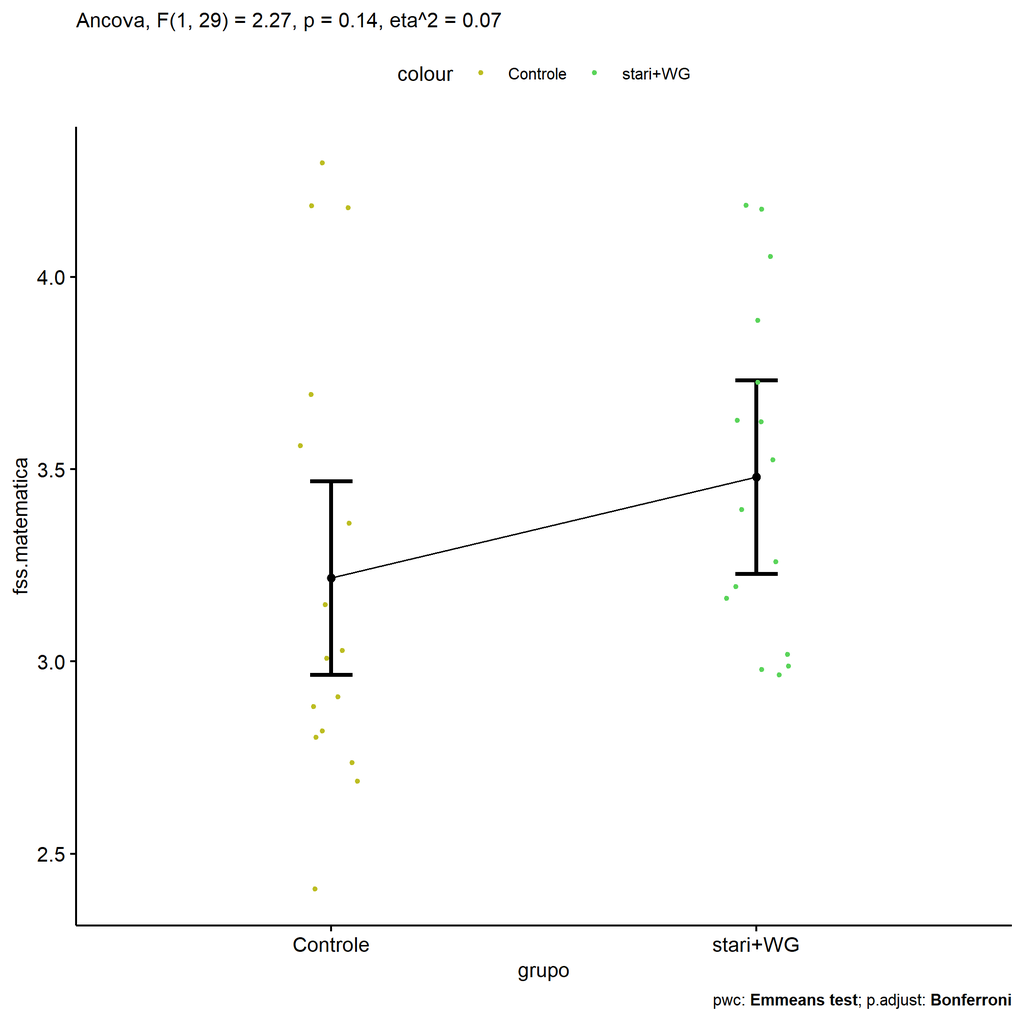

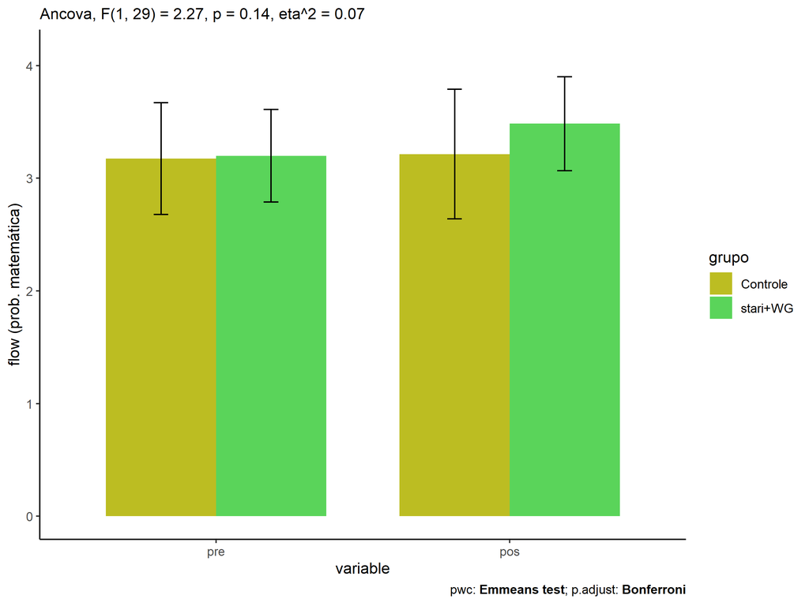

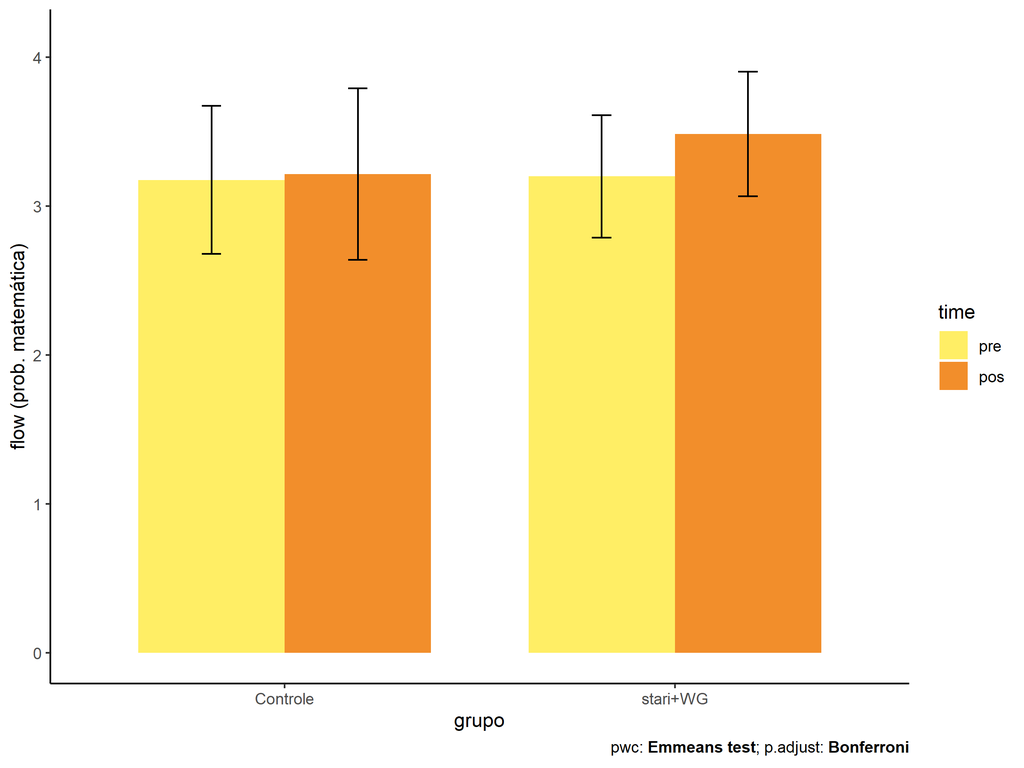

### factor: **genero**

| var | genero | n | M (pre) | SE (pre) | M (unadj) | SE (unadj) | M (adj) | SE (adj) |
| --- | --- | --- | --- | --- | --- | --- | --- | --- |
| fss.matematica | F | 10 | 3.022 | 0.125 | 3.50 | 0.187 | 3.565 | 0.158 |
| fss.matematica | M | 22 | 3.261 | 0.098 | 3.28 | 0.101 | 3.250 | 0.105 |

| .y. | group1 | group2 | estimate | conf.low | conf.high | se | statistic | p | p.adj | p.adj.signif |
| --- | --- | --- | --- | --- | --- | --- | --- | --- | --- | --- |
| fss.matematica | F | M | 0.315 | -0.079 | 0.709 | 0.193 | 1.633 | 0.113 | 0.113 | ns |
| dfs.matematica | F | M | -0.239 | -0.583 | 0.105 | 0.168 | -1.416 | 0.167 | 0.167 | ns |

| .y. | genero | group1 | group2 | estimate | conf.low | conf.high | se | statistic | p | p.adj | p.adj.signif |
| --- | --- | --- | --- | --- | --- | --- | --- | --- | --- | --- | --- |
| flow.matematica | F | pre | pos | -0.478 | -0.905 | -0.050 | 0.214 | -2.236 | 0.029 | 0.029 | * |
| flow.matematica | M | pre | pos | -0.019 | -0.307 | 0.269 | 0.144 | -0.131 | 0.896 | 0.896 | ns |

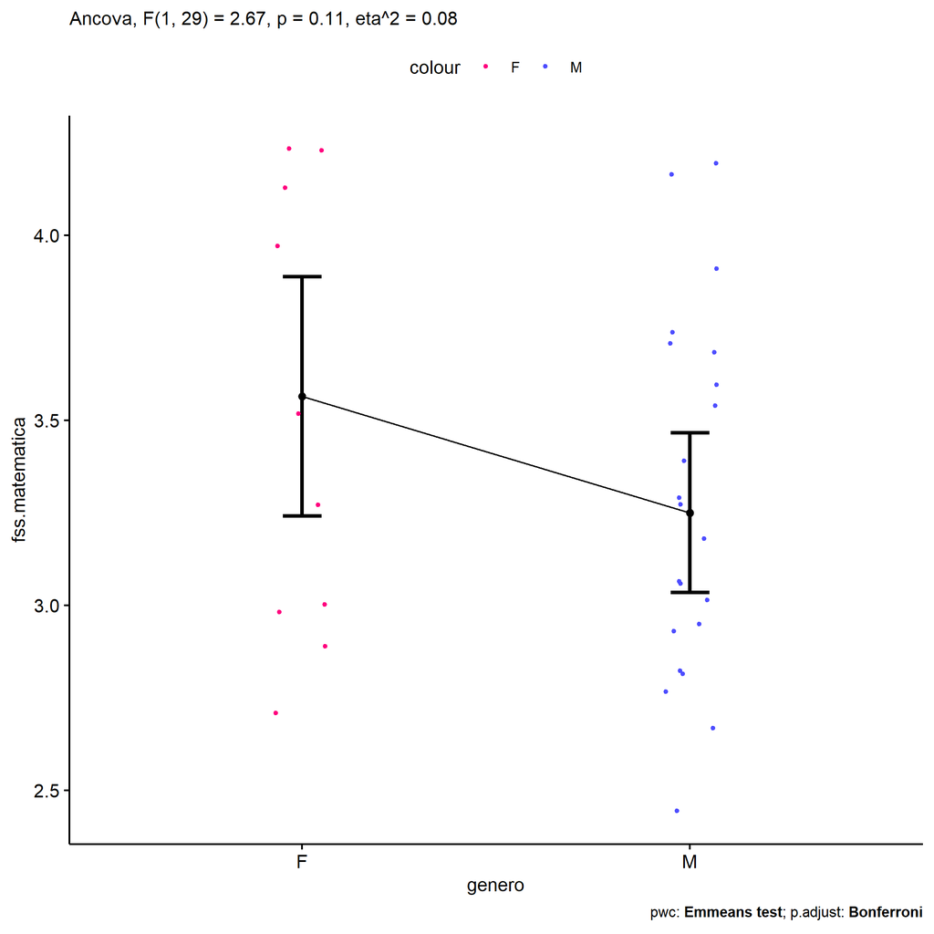

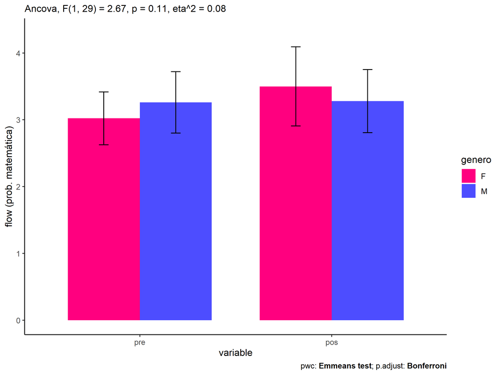

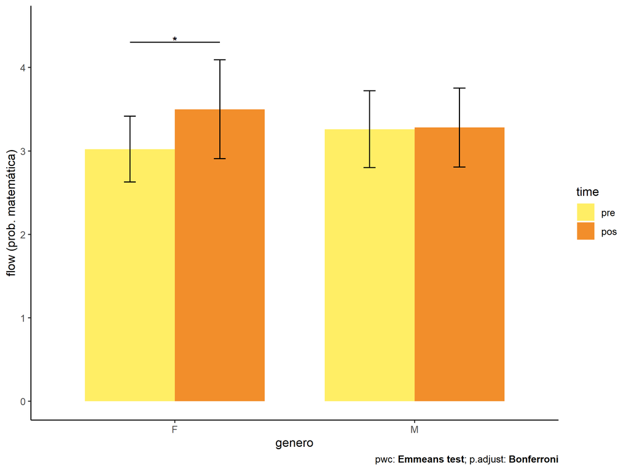

### factor: **idade**

| var | idade | n | M (pre) | SE (pre) | M (unadj) | SE (unadj) | M (adj) | SE (adj) |
| --- | --- | --- | --- | --- | --- | --- | --- | --- |
| fss.matematica | 10y | 6 | 3.185 | 0.229 | 3.593 | 0.243 | 3.589 | 0.210 |
| fss.matematica | 11y | 17 | 3.154 | 0.094 | 3.319 | 0.115 | 3.320 | 0.125 |

| .y. | group1 | group2 | estimate | conf.low | conf.high | se | statistic | p | p.adj | p.adj.signif |
| --- | --- | --- | --- | --- | --- | --- | --- | --- | --- | --- |
| fss.matematica | 10y | 11y | 0.270 | -0.241 | 0.78 | 0.245 | 1.103 | 0.283 | 0.283 | ns |
| dfs.matematica | 10y | 11y | 0.031 | -0.399 | 0.46 | 0.207 | 0.149 | 0.883 | 0.883 | ns |

| .y. | idade | group1 | group2 | estimate | conf.low | conf.high | se | statistic | p | p.adj | p.adj.signif |
| --- | --- | --- | --- | --- | --- | --- | --- | --- | --- | --- | --- |
| flow.matematica | 10y | pre | pos | -0.407 | -0.957 | 0.142 | 0.272 | -1.495 | 0.142 | 0.142 | ns |
| flow.matematica | 11y | pre | pos | -0.164 | -0.491 | 0.162 | 0.162 | -1.015 | 0.316 | 0.316 | ns |

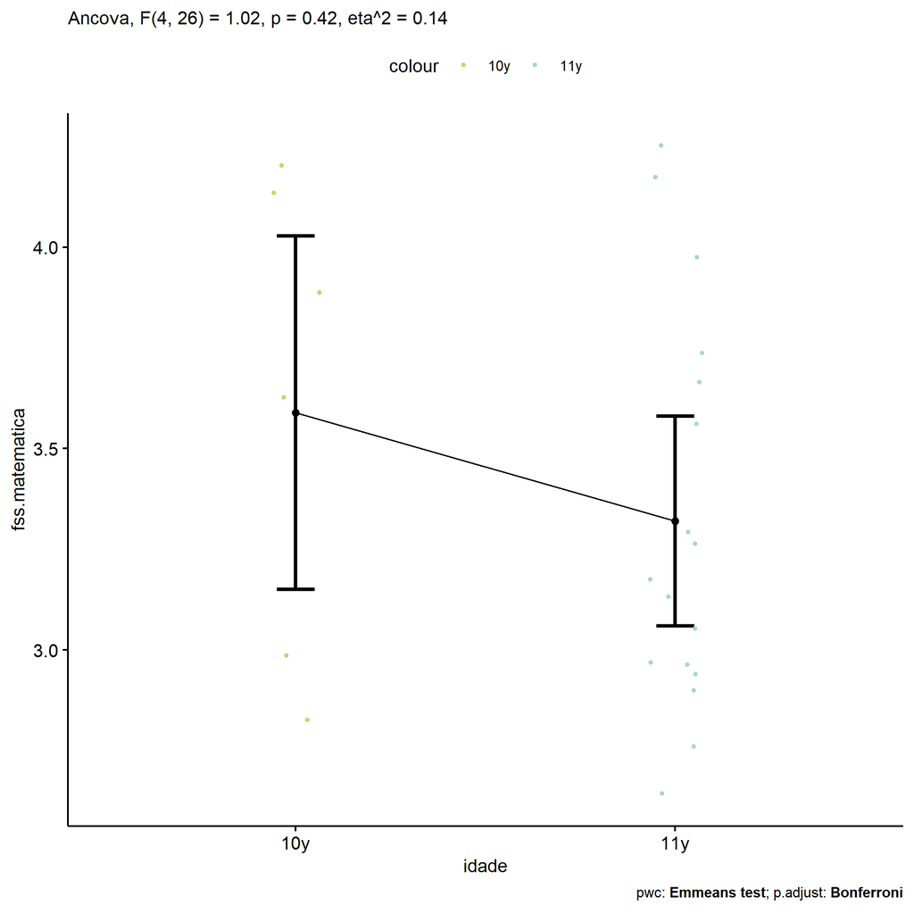

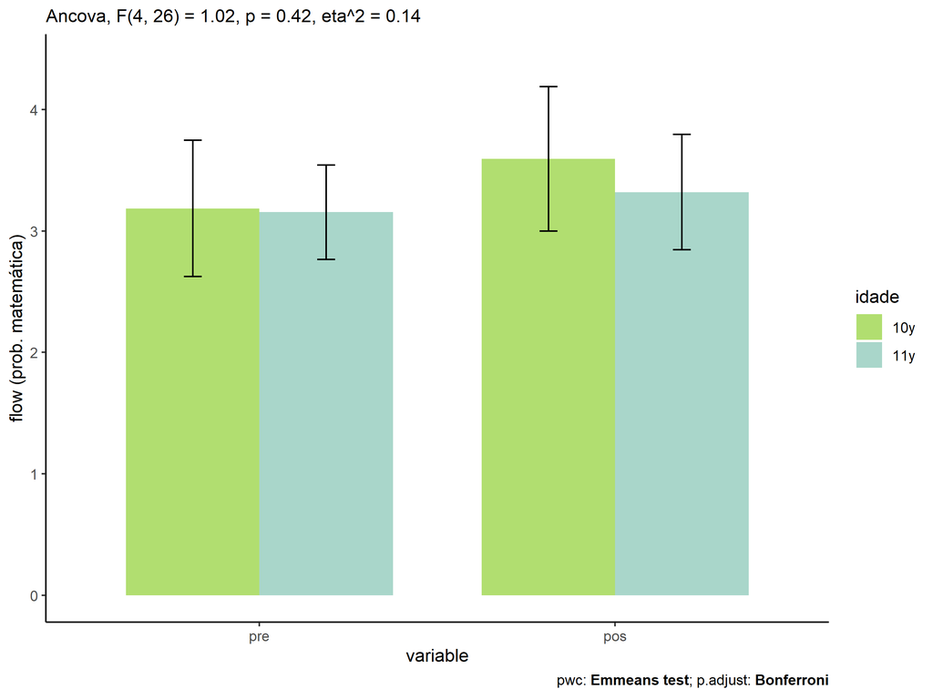

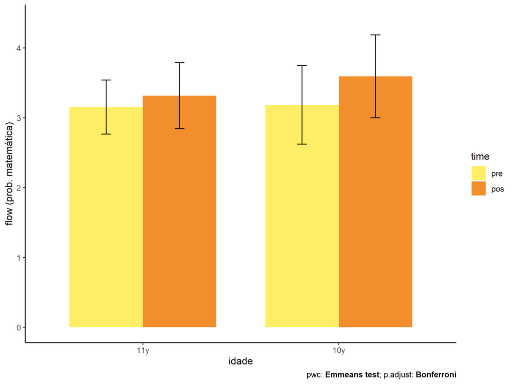

### factor: **zona.participante**

| var | zona.participante | n | M (pre) | SE (pre) | M (unadj) | SE (unadj) | M (adj) | SE (adj) |
| --- | --- | --- | --- | --- | --- | --- | --- | --- |
| fss.matematica | Rural | 7 | 3.129 | 0.163 | 3.365 | 0.187 | 3.385 | 0.209 |
| fss.matematica | Urbana | 16 | 3.205 | 0.114 | 3.379 | 0.147 | 3.371 | 0.138 |

| .y. | group1 | group2 | estimate | conf.low | conf.high | se | statistic | p | p.adj | p.adj.signif |
| --- | --- | --- | --- | --- | --- | --- | --- | --- | --- | --- |
| fss.matematica | Urbana | Rural | -0.015 | -0.537 | 0.508 | 0.250 | -0.058 | 0.954 | 0.954 | ns |
| dfs.matematica | Urbana | Rural | 0.076 | -0.349 | 0.501 | 0.204 | 0.371 | 0.714 | 0.714 | ns |

| .y. | zona.participante | group1 | group2 | estimate | conf.low | conf.high | se | statistic | p | p.adj | p.adj.signif |
| --- | --- | --- | --- | --- | --- | --- | --- | --- | --- | --- | --- |
| flow.matematica | Urbana | pre | pos | -0.174 | -0.539 | 0.190 | 0.181 | -0.966 | 0.339 | 0.339 | ns |
| flow.matematica | Rural | pre | pos | -0.236 | -0.787 | 0.315 | 0.273 | -0.865 | 0.392 | 0.392 | ns |

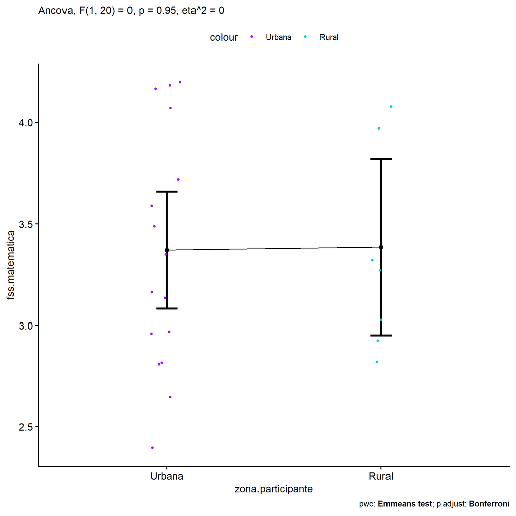

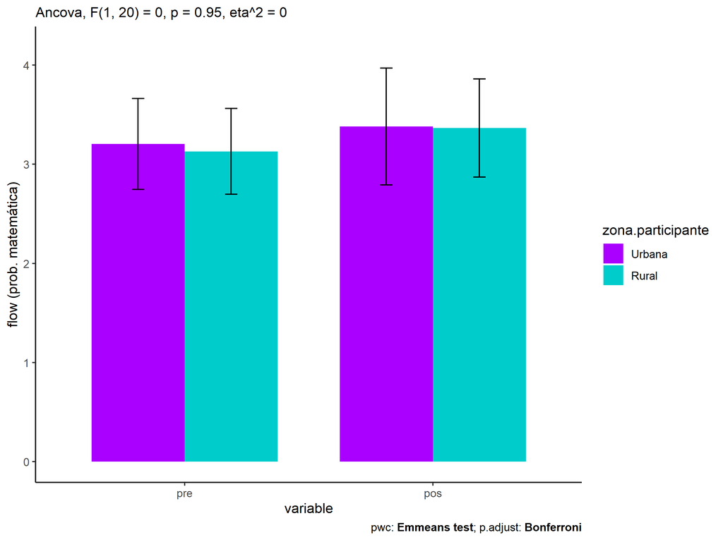

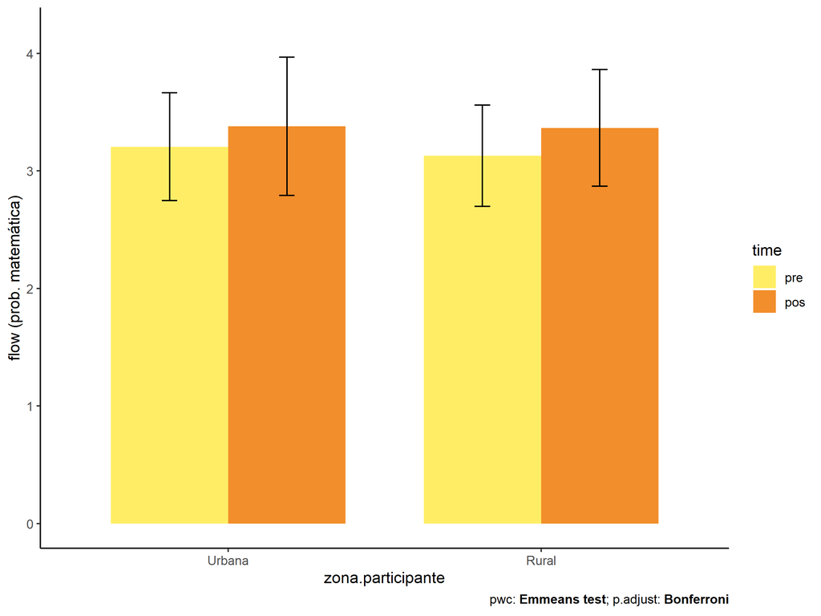

### factor: **escola**

| var | escola | n | M (pre) | SE (pre) | M (unadj) | SE (unadj) | M (adj) | SE (adj) |
| --- | --- | --- | --- | --- | --- | --- | --- | --- |
| fss.matematica | E1 | 6 | 2.870 | 0.191 | 3.000 | 0.257 | 3.029 | 0.231 |
| fss.matematica | E4 | 6 | 3.472 | 0.214 | 3.586 | 0.127 | 3.556 | 0.232 |
| fss.matematica | E5 | 13 | 3.163 | 0.120 | 3.374 | 0.153 | 3.374 | 0.149 |

| .y. | group1 | group2 | estimate | conf.low | conf.high | se | statistic | p | p.adj | p.adj.signif |
| --- | --- | --- | --- | --- | --- | --- | --- | --- | --- | --- |
| fss.matematica | E1 | E4 | -0.526 | -1.242 | 0.189 | 0.344 | -1.529 | 0.141 | 0.423 | ns |
| fss.matematica | E1 | E5 | -0.345 | -0.917 | 0.227 | 0.275 | -1.255 | 0.223 | 0.670 | ns |
| fss.matematica | E4 | E5 | 0.181 | -0.393 | 0.755 | 0.276 | 0.657 | 0.518 | 1.000 | ns |
| dfs.matematica | E1 | E4 | -0.602 | -1.155 | -0.048 | 0.267 | -2.255 | 0.034 | 0.103 | ns |
| dfs.matematica | E1 | E5 | -0.293 | -0.766 | 0.180 | 0.228 | -1.285 | 0.212 | 0.637 | ns |
| dfs.matematica | E4 | E5 | 0.309 | -0.164 | 0.782 | 0.228 | 1.353 | 0.190 | 0.569 | ns |

| .y. | escola | group1 | group2 | estimate | conf.low | conf.high | se | statistic | p | p.adj | p.adj.signif |
| --- | --- | --- | --- | --- | --- | --- | --- | --- | --- | --- | --- |
| flow.matematica | E1 | pre | pos | -0.130 | -0.706 | 0.447 | 0.286 | -0.453 | 0.653 | 0.653 | ns |
| flow.matematica | E4 | pre | pos | -0.113 | -0.690 | 0.463 | 0.286 | -0.396 | 0.694 | 0.694 | ns |
| flow.matematica | E5 | pre | pos | -0.210 | -0.602 | 0.181 | 0.194 | -1.083 | 0.285 | 0.285 | ns |

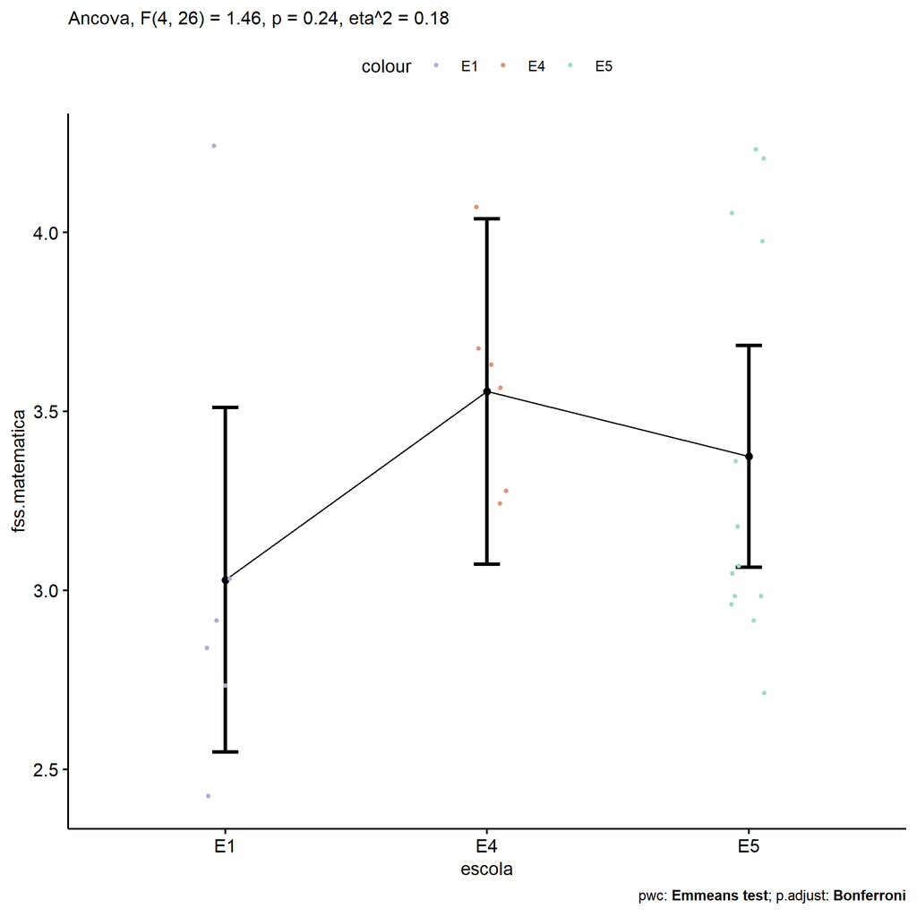

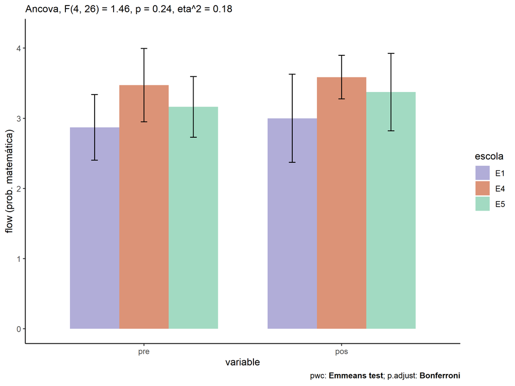

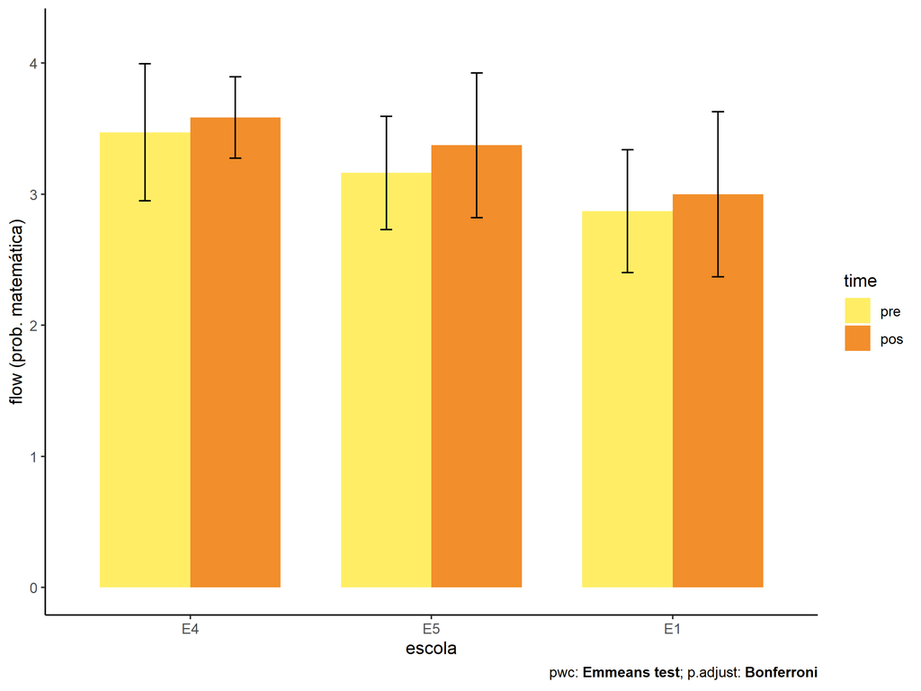